# Activity 2 — Task 1: Data Preprocessing

Group 08

# 1 Data Preprocessing

## 1.1 Dataset Description

The dataset used in this analysis is derived from the Open Sourcing Mental Illness (OSMI) survey spanning five consecutive years (2018–2022). The survey aims to measure attitudes towards mental health in the technology workplace.

To ensure statistical reliability and focus on our specific research questions, we extracted the following core variables from all five datasets.

### Target Variables

- **Treatment**: whether the employee sought professional treatment for a mental health condition.
- **Employer_Mental_Importance**: the importance placed on mental health by the employer, measured on a numerical scale.

### Predictor Variables

- **Demographics**: Age, Gender, Family_History
- **Corporate environment factors**:
  - Tech_Company
  - Employer_Phys_Importance
  - Coworker_Reaction_Score
  - Industry_Support_Rating

The survey structure changes slightly between years, so the preprocessing procedure uses column-name matching rather than relying on fixed column positions.

## 1.2 Data Integration

A helper function is used to extract the required variables from each yearly dataset. Regular expressions are used to identify columns because column names are not necessarily identical across survey years.

```r
library(tidyverse)
library(scales)
```

```r
load_osmi <- function(file_path, year) {

  df <- read.csv(
    file_path,
    stringsAsFactors = FALSE,
    check.names = FALSE
  )

  get_col <- function(pattern, required = TRUE) {

    matched <- grep(
      pattern,
      names(df),
      value = TRUE,
      ignore.case = TRUE
    )

    if (length(matched) == 0) {

      if (required) {
        stop(
          paste0(
            "Column not found for pattern: ",
            pattern,
            "\nFile: ",
            file_path
          )
        )
      } else {
        return(NULL)
      }
    }

    matched[1]
  }

  tibble(
    Age = suppressWarnings(
      as.numeric(df[[get_col("^what is your age|\\bage\\b")]])
    ),

    Gender = as.character(
      df[[get_col("what is your gender|^gender")]]
    ),

    Treatment = df[[
      get_col("sought treatment for a mental health")
    ]],

    Tech_Company = df[[
      get_col("primarily a tech company")
    ]],

    Employer_Phys_Importance = suppressWarnings(
      as.numeric(
        df[[
          get_col(
            "importance does your employer place on physical"
          )
        ]]
      )
    ),

    Employer_Mental_Importance = suppressWarnings(
      as.numeric(
        df[[
          get_col(
            "importance does your employer place on mental"
          )
        ]]
      )
    ),

    Coworker_Reaction_Score = suppressWarnings(
      as.numeric(
        df[[
          get_col(
            "team members/co-workers would react|co-workers would react"
          )
        ]]
      )
    ),

    Industry_Support_Rating = suppressWarnings(
      as.numeric(
        df[[
          get_col(
            "tech industry supports employees"
          )
        ]]
      )
    ),

    Family_History = as.character(
      df[[
        get_col("family history of mental")
      ]]
    ),

    Year = as.integer(year)
  )
}

data <- bind_rows(

  load_osmi(
    "dataset/OSMI_Mental_Health_In_Teach_Industry_2018.csv",
    2018
  ),

  load_osmi(
    "dataset/OSMI_Mental_Health_In_Teach_Industry_2019.csv",
    2019
  ),

  load_osmi(
    "dataset/OSMI_Mental_Health_In_Teach_Industry_2020.csv",
    2020
  ),

  load_osmi(
    "dataset/OSMI_Mental_Health_In_Teach_Industry_2021.csv",
    2021
  ),

  load_osmi(
    "dataset/OSMI_Mental_Health_In_Teach_Industry_2022.csv",
    2022
  )
)

cat(
  "Initial combined rows:",
  nrow(data),
  "\n"
)
```

```
## Initial combined rows: 1244
```

## 1.3 Handle Missing Values

First, we inspect the number of missing values in each variable.

```r
missing_values <- colSums(is.na(data))

print(missing_values)
```

```
##                        Age                     Gender
##                          0                          0
##                  Treatment               Tech_Company
##                          0                        186
##   Employer_Phys_Importance Employer_Mental_Importance
##                        186                        186
##    Coworker_Reaction_Score    Industry_Support_Rating
##                          0                          0
##             Family_History                       Year
##                          0                          0
```

The three corporate-specific variables (`Employer_Mental_Importance`, `Employer_Phys_Importance`, and `Tech_Company`) are required for the corporate workplace analysis.

Freelancers and self-employed respondents may legitimately have missing values for these questions because they are not applicable to their employment situation. Therefore, rows with missing values in these three variables are removed.

Missing values in other independent variables, such as `Gender`, are initially retained in order to avoid unnecessarily reducing the sample size.

```r
data <- data %>%
  drop_na(
    Employer_Mental_Importance,
    Employer_Phys_Importance,
    Tech_Company
  )

cat(
  "Rows after removing rows with missing corporate variables:",
  nrow(data),
  "\n"
)
```

```
## Rows after removing rows with missing corporate variables: 1058
```

## 1.4 Remove Duplicate Records

Duplicate observations are identified before removing them.

```r
duplicate_rows <- data[duplicated(data), ]

cat(
  "Number of duplicate rows:",
  nrow(duplicate_rows),
  "\n"
)
```

```
## Number of duplicate rows: 1
```

Duplicate observations are then removed using `distinct()`.

```r
data <- data %>%
  distinct()

cat(
  "Rows after removing duplicates:",
  nrow(data),
  "\n"
)
```

```
## Rows after removing duplicates: 1057
```

## 1.5 Detect and Handle Outliers in Age

Age is examined using a boxplot to identify potentially invalid observations.

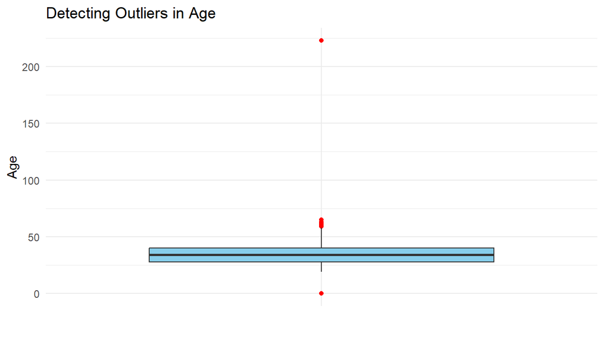

```r
ggplot(
  data,
  aes(x = "", y = Age)
) +
  geom_boxplot(
    fill = "skyblue",
    outlier.color = "red",
    outlier.shape = 16
  ) +
  theme_minimal() +
  labs(
    title = "Detecting Outliers in Age",
    x = "",
    y = "Age"
  )
```

### Age Validation

Unlike variables such as income or salary, extremely large or extremely small age values are not realistic for a working population.

Therefore, we restrict the dataset to respondents between **18 and 65 years old**.

```r
data <- data %>%
  filter(
    !is.na(Age),
    Age >= 18,
    Age <= 65
  )

cat(
  "Rows after filtering valid working age:",
  nrow(data),
  "\n"
)
```

```
## Rows after filtering valid working age: 1055
```

## 1.6 Normalize and Encode Categorical Variables

### Gender Normalization

Gender responses were collected using free-text input, which resulted in multiple representations of the same category.

We normalize the text by trimming whitespace and converting values to lowercase before mapping them into three broad categories: **Female**, **Male**, and **Other**.

```r
data <- data %>%
  mutate(
    Gender = str_trim(
      str_to_lower(Gender)
    ),

    Gender_Category = case_when(

      str_detect(
        Gender,
        "^(f|female|woman|cis female|femmina)"
      ) ~ "Female",

      str_detect(
        Gender,
        "^(m|male|man|cis male|dude|masculin)"
      ) ~ "Male",

      TRUE ~ "Other"
    )
  )

print(
  table(
    data$Gender_Category,
    useNA = "ifany"
  )
)
```

```
##
## Female   Male  Other
##    320    669     66
```

The normalization ensures that missing or unusual responses are assigned to the `Other` category rather than creating many small categories.

### Binary Encoding

The `Treatment` and `Tech_Company` variables are converted into binary categorical variables.

```r
data <- data %>%
  mutate(

    Treatment_Cat = case_when(
      Treatment == 1 ~ "Yes",
      str_detect(
        str_to_lower(as.character(Treatment)),
        "^yes$"
      ) ~ "Yes",
      TRUE ~ "No"
    ),

    Tech_Company_Cat = case_when(
      Tech_Company == 1 ~ "Yes",
      str_detect(
        str_to_lower(as.character(Tech_Company)),
        "^yes$"
      ) ~ "Yes",
      TRUE ~ "No"
    )
  )
```

### One-Hot Encoding

Nominal categorical variables are encoded using dummy variables.

For interpretation, the reference categories are explicitly defined as:

- **Male** for gender
- **No** for family history

```r
one_hot <- function(
  df,
  col,
  prefix,
  ref_level
) {

  f <- factor(
    df[[col]]
  )

  f <- relevel(
    f,
    ref = ref_level
  )

  mm <- model.matrix(
    ~ f,
    data = data.frame(f = f)
  )

  mm <- as.data.frame(
    mm[, -1, drop = FALSE]
  )

  if (ncol(mm) > 0) {

    colnames(mm) <- paste0(
      prefix,
      gsub(
        "[^[:alnum:]]",
        "_",
        levels(f)[-1]
      )
    )
  }

  mm
}
```

The dummy variables are then added to the dataset.

```r
gender_dummy <- one_hot(
  data,
  "Gender_Category",
  "gender_",
  "Male"
)

family_dummy <- one_hot(
  data,
  "Family_History",
  "fam_hist_",
  "No"
)

data <- bind_cols(
  data,
  gender_dummy,
  family_dummy
)
```

The target variables and binary categorical variables are explicitly converted to factors, with `No` as the reference category.

```r
data$Treatment_Cat <- factor(
  data$Treatment_Cat,
  levels = c("No", "Yes")
)

data$Tech_Company_Cat <- factor(
  data$Tech_Company_Cat,
  levels = c("No", "Yes")
)

data$Year <- factor(data$Year)
```

## 1.7 Scale Numerical Features

Numerical predictor variables are standardized using Z-score normalization:

$$Z = \frac{X - \mu}{\sigma}$$

The original variables are preserved so that regression coefficients based on the original scale remain interpretable.

```r
data$Age_scaled <- as.numeric(
  scale(data$Age)
)

data$Employer_Phys_scaled <- as.numeric(
  scale(data$Employer_Phys_Importance)
)

data$Employer_Mental_scaled <- as.numeric(
  scale(data$Employer_Mental_Importance)
)

data$Coworker_Reaction_scaled <- as.numeric(
  scale(data$Coworker_Reaction_Score)
)
```

## 1.8 Final Verification and Export

The final dataset is checked for the number of observations and the distribution of gender and treatment.

```r
cat(
  "Final Rows:",
  nrow(data),
  "\n"
)
```

```
## Final Rows: 1055
```

```r
cat(
  "Final Columns:",
  ncol(data),
  "\n"
)
```

```
## Final Columns: 21
```

```r
print(
  table(
    data$Gender_Category,
    data$Treatment_Cat,
    useNA = "ifany"
  )
)
```

```
##
##           No Yes
##   Female 111 209
##   Male   315 354
##   Other   20  46
```

A summary of the final dataset can also be inspected.

```r
str(data)
```

```
## tibble [1,055 × 21] (S3: tbl_df/tbl/data.frame)
##  $ Age                       : num [1:1055] 57 29 46 34 29 55 29 35 33 37 ...
##  $ Gender                    : chr [1:1055] "female" "male" "male" "male" ...
##  $ Treatment                 : int [1:1055] 1 1 0 0 1 0 1 1 0 0 ...
##  $ Tech_Company              : int [1:1055] 1 1 0 1 1 1 1 1 1 0 ...
##  $ Employer_Phys_Importance  : num [1:1055] 8 8 3 8 7 7 4 10 10 3 ...
##  $ Employer_Mental_Importance: num [1:1055] 6 3 1 8 5 8 4 8 0 1 ...
##  $ Coworker_Reaction_Score   : num [1:1055] 5 3 9 5 5 5 5 8 0 1 ...
##  $ Industry_Support_Rating   : num [1:1055] 2 3 3 1 4 3 2 4 1 1 ...
##  $ Family_History            : chr [1:1055] "Yes" "Yes" "Yes" "No" ...
##  $ Year                      : Factor w/ 5 levels "2018","2019",..: 1 1 1 1 1 1 1 1 1 1 ...
##  $ Gender_Category           : chr [1:1055] "Female" "Male" "Male" "Male" ...
##  $ Treatment_Cat             : Factor w/ 2 levels "No","Yes": 2 2 1 1 2 1 2 2 1 1 ...
##  $ Tech_Company_Cat          : Factor w/ 2 levels "No","Yes": 2 2 1 2 2 2 2 2 2 1 ...
##  $ gender_Female             : num [1:1055] 1 0 0 0 0 0 0 0 0 0 ...
##  $ gender_Other              : num [1:1055] 0 0 0 0 1 0 1 0 0 0 ...
##  $ fam_hist_I_don_t_know     : num [1:1055] 0 0 0 0 0 0 0 1 0 0 ...
##  $ fam_hist_Yes              : num [1:1055] 1 1 1 0 1 0 0 0 1 0 ...
##  $ Age_scaled                : num [1:1055] 2.523 -0.673 1.267 -0.102 -0.673 ...
##  $ Employer_Phys_scaled      : num [1:1055] 0.738 0.738 -1.403 0.738 0.31 ...
##  $ Employer_Mental_scaled    : num [1:1055] 0.374 -0.7876 -1.562 1.1483 -0.0132 ...
##  $ Coworker_Reaction_scaled  : num [1:1055] -0.159 -1.008 1.539 -0.159 -0.159 ...
```

```r
summary(data)
```

```
##       Age             Gender       Treatment       Tech_Company
##  Min.   :19.0   Length   :1055   Min.   :0.0000   Min.   :0.0000
##  1st Qu.:28.0   N.unique :  65   1st Qu.:0.0000   1st Qu.:0.0000
##  Median :34.0   N.blank  :  10   Median :1.0000   Median :1.0000
##  Mean   :34.9   Min.nchar:   0   Mean   :0.5773   Mean   :0.6891
##  3rd Qu.:40.0   Max.nchar:  35   3rd Qu.:1.0000   3rd Qu.:1.0000
##  Max.   :65.0                    Max.   :1.0000   Max.   :1.0000
##  Employer_Phys_Importance Employer_Mental_Importance Coworker_Reaction_Score
##  Min.   : 0.000           Min.   : 0.000             Min.   : 0.000
##  1st Qu.: 5.000           1st Qu.: 3.000             1st Qu.: 4.000
##  Median : 7.000           Median : 5.000             Median : 5.000
##  Mean   : 6.277           Mean   : 5.034             Mean   : 5.375
##  3rd Qu.: 8.000           3rd Qu.: 7.000             3rd Qu.: 7.000
##  Max.   :10.000           Max.   :10.000             Max.   :10.000
##  Industry_Support_Rating   Family_History   Year      Gender_Category
##  Min.   :1.000           Length   :1055   2018:361   Length   :1055
##  1st Qu.:2.000           N.unique :   3   2019:302   N.unique :   3
##  Median :3.000           N.blank  :   0   2020:155   N.blank  :   0
##  Mean   :2.635           Min.nchar:   2   2021:113   Min.nchar:   4
##  3rd Qu.:3.000           Max.nchar:  12   2022:124   Max.nchar:   6
##  Max.   :5.000
##  Treatment_Cat Tech_Company_Cat gender_Female     gender_Other
##  No :446       No :328          Min.   :0.0000   Min.   :0.00000
##  Yes:609       Yes:727          1st Qu.:0.0000   1st Qu.:0.00000
##                                 Median :0.0000   Median :0.00000
##                                 Mean   :0.3033   Mean   :0.06256
##                                 3rd Qu.:1.0000   3rd Qu.:0.00000
##                                 Max.   :1.0000   Max.   :1.00000
##  fam_hist_I_don_t_know  fam_hist_Yes      Age_scaled      Employer_Phys_scaled
##  Min.   :0.0000        Min.   :0.0000   Min.   :-1.8145   Min.   :-2.6866
##  1st Qu.:0.0000        1st Qu.:0.0000   1st Qu.:-0.7873   1st Qu.:-0.5465
##  Median :0.0000        Median :0.0000   Median :-0.1025   Median : 0.3096
##  Mean   :0.2114        Mean   :0.4265   Mean   : 0.0000   Mean   : 0.0000
##  3rd Qu.:0.0000        3rd Qu.:1.0000   3rd Qu.: 0.5824   3rd Qu.: 0.7376
##  Max.   :1.0000        Max.   :1.0000   Max.   : 3.4358   Max.   : 1.5936
##  Employer_Mental_scaled Coworker_Reaction_scaled
##  Min.   :-1.94914       Min.   :-2.2818
##  1st Qu.:-0.78758       1st Qu.:-0.5838
##  Median :-0.01321       Median :-0.1593
##  Mean   : 0.00000       Mean   : 0.0000
##  3rd Qu.: 0.76116       3rd Qu.: 0.6896
##  Max.   : 1.92271       Max.   : 1.9631
```

Finally, the cleaned dataset is exported as a CSV file for subsequent statistical analysis.

```r
write.csv(
  data,
  "dataset/osmi_clean_combined.csv",
  row.names = FALSE
)

cat(
  "Cleaned dataset exported successfully.\n"
)
```

```
## Cleaned dataset exported successfully.
```